# ADEGOKE_HW5

Abimbola

2022-10-30

### The main aim of the task is to import data into R, perform brief explanatory analysis, build at least one plot

### Export data using R Markdown and ‘knit’ by creating an html.file

### 1. Go to https://andmed.stat.ee/en/stat and create a data set you want to explore. Import the data into R.

#installing the required packages

#install.packages(“stats”)

#install.packages(“dplyr”)

#Importing and storing the dataset in mydata

#Loading the required libraries (library function helps to invoke the content of the packages)

```r
library(stats)
library(dplyr)
```

Importing my dataset()

Data analysis and graph plotting will cover between 2008 and 2010.

```r
mydata<-read.csv("C:/Users/oladayo/Desktop/School Work/My R Project/Abimbola/test.csv")
mydata
```

```
##                           Type.of.broadcast
## 1  Broadcasts total (excluding advertising)
## 2                          ..own production
## 3                    ..repeat transmissions
## 4                 ..broadcasts for children
## 5                    ..broadcasts for youth
## 6                                      News
## 7                    Informative broadcasts
## 8                    Educational broadcasts
## 9              Broadcasts of human interest
## 10       Cultural and scientific broadcasts
## 11                     Religious broadcasts
## 12                         Music broadcasts
## 13                        Sports broadcasts
## 14                           ..competitions
```

[output cut: 375 more lines]

#To evaluate the structure of the data

```r
str(mydata)
```

```
## 'data.frame':    25 obs. of  29 variables:
##  $ Type.of.broadcast                    : chr  "Broadcasts total (excluding advertising)" "..own production" "..repeat transmissions" "..broadcasts for children" ...
##  $ X2008.Duration.of.broadcasts..minutes: int  880 381 305 40 135 84 35 4 71 23 ...
##  $ X2008.Share.of.broadcasts...         : num  100 43.3 34.7 4.5 15.4 9.6 4 0.5 8.1 2.6 ...
##  $ X2009.Duration.of.broadcasts..minutes: int  939 411 342 34 45 58 23 7 63 17 ...
##  $ X2009.Share.of.broadcasts...         : num  100 43.8 36.4 3.6 4.8 6.2 2.4 0.7 6.7 1.8 ...
##  $ X2010.Duration.of.broadcasts..minutes: int  921 312 356 31 56 62 24 6 68 20 ...
##  $ X2010.Share.of.broadcasts...         : num  100 33.9 38.6 3.4 6.1 6.7 2.6 0.7 7.3 2.2 ...
##  $ X2011.Duration.of.broadcasts..minutes: int  889 253 532 32 38 68 27 8 79 34 ...
##  $ X2011.Share.of.broadcasts...         : num  100 28.5 59.8 3.6 4.2 7.7 3.1 0.9 8.9 3.8 ...
##  $ X2012.Duration.of.broadcasts..minutes: int  943 254 526 33 38 86 30 9 105 33 ...
##  $ X2012.Share.of.broadcasts...         : num  100 28.6 59.1 3.7 4.3 9.6 3.3 1 11.8 3.7 ...
##  $ X2013.Duration.of.broadcasts..minutes: int  953 271 450 91 31 78 42 6 101 32 ...
##  $ X2013.Share.of.broadcasts...         : num  100 28.4 47.2 9.5 3.3 8.2 4.4 0.6 10.6 3.4 ...
##  $ X2014.Duration.of.broadcasts..minutes: int  968 261 452 105 37 78 38 13 78 17 ...
##  $ X2014.Share.of.broadcasts...         : num  100 27 46.7 10.8 3.8 8.1 3.9 1.3 8.1 1.8 ...
##  $ X2015.Duration.of.broadcasts..minutes: int  907 170 400 97 63 53 19 2 55 14 ...
##  $ X2015.Share.of.broadcasts...         : num  100 18.7 44.1 10.7 6.9 5.8 2.1 0.2 6.1 1.5 ...
##  $ X2016.Duration.of.broadcasts..minutes: int  1038 311 428 118 29 82 23 1 72 12 ...
##  $ X2016.Share.of.broadcasts...         : num  100 30 41.2 11.4 2.8 7.9 2.2 0.1 6.9 1.2 ...
##  $ X2017.Duration.of.broadcasts..minutes: int  1063 439 395 127 30 105 43 1 54 11 ...
##  $ X2017.Share.of.broadcasts...         : num  100 41.3 37.2 11.9 2.8 9.9 4 0.1 5.1 1 ...
##  $ X2018.Duration.of.broadcasts..minutes: int  1080 415 333 150 61 50 47 46 34 15 ...
##  $ X2018.Share.of.broadcasts...         : num  100 38.4 30.8 13.9 5.6 4.6 4.4 4.3 3.1 1.4 ...
##  $ X2019.Duration.of.broadcasts..minutes: int  1180 352 357 166 49 57 51 2 70 15 ...
##  $ X2019.Share.of.broadcasts...         : num  100 29.8 30.3 14.1 4.2 4.8 4.3 0.2 5.9 1.3 ...
##  $ X2020.Duration.of.broadcasts..minutes: int  1147 248 467 152 47 48 101 1 35 12 ...
##  $ X2020.Share.of.broadcasts...         : num  100 21.6 40.7 13.3 4.1 4.2 8.8 0.1 3.1 1 ...
##  $ X2021.Duration.of.broadcasts..minutes: int  1139 197 355 168 41 43 63 1 28 9 ...
##  $ X2021.Share.of.broadcasts...         : num  100 17.3 31.2 14.7 3.6 3.8 5.5 0.1 2.5 0.8 ...
```

### 2. Prepare EDA (Explanatory Data Analysis). Write at least 5 questions and provide your answers during the first stage of EDA.

### Data summarization

#Preparing a dataset for the Duration of broadcasts and Share of broadcasts for 2008

```r
Db2008 = mydata$X2008.Duration.of.broadcasts..minutes
SB2008 = mydata$X2008.Share.of.broadcasts...
```

### Question 1: What metadata is available?

The data is from - KU138: Mean Daily Duration of Broadcasting per TV-Broadcaster by Type of Broadcast - a subdivision of broadcasting and culture in the culture dataset.

### Question 2: Observed population and reference period

There are 25 observations and 29 variables with data comparison of duration of broadcast and share of broadcast between the year 2008 and 2021

### Question 3: What are the data types of the variables?

The datatypes include characters, integers and numbers

### Question 4: Are there any outliers?

Graphs plotted below show that there are a few outliers in the duration of broadcast in 2008 as well as share of broadcast in 2008. In 2009 as well, there are two outliers each in both duration of broadcast and share of broadcast.

### Question 5: central Tendencies

calculating the mean

```r
mean(Db2008)    #118.96
```

```
## [1] 118.96
```

```r
mean(SB2008)    #13.532
```

```
## [1] 13.532
```

Calculating the median

```r
median(Db2008)  #69
```

```
## [1] 69
```

```r
median(SB2008)  #7.9
```

```
## [1] 7.9
```

calculating the mode

```r
mode = function(x){
  ta = table(x)
  tam = max(ta)
  if(all(ta == tam))
    mod = NA
  else
    if(is.numeric(x))
      mod = as.numeric(names(ta)[ta == tam])
  else
    mod = names(ta)[ta == tam]
  return(mod)
}
mode(Db2008) # 1    3 137
```

```
## [1]   1   3 137
```

```r
mode(SB2008)# 0.1 0.4
```

```
## [1] 0.1 0.4
```

### Measuring the variability

calculating the standard Deviation

```r
sd(Db2008) # 189.1057
```

```
## [1] 189.1057
```

```r
sd(SB2008) #21.48485
```

```
## [1] 21.48485
```

calculating IQR

```r
quantile(Db2008) # 1   13 69 135 880
```

```
##   0%  25%  50%  75% 100%
##    1   13   69  135  880
```

```r
quantile(SB2008)#    0.1 1.5 7.9 15.4 100.0
```

```
##    0%   25%   50%   75%  100%
##   0.1   1.5   7.9  15.4 100.0
```

### 3. Provide brief descriptive statistical analysis of your data set (like measures of central tendency and dispersion).

calculating variance where standard deviation measures how much data values are deviated from mean

```r
var(Db2008) #35760.96
```

```
## [1] 35760.96
```

```r
var(SB2008) #461.5989
```

```
## [1] 461.5989
```

### 4. Include at least one plot into your report. If ggplot2 is too complicated for you now, create a plot with R base functions.

numeric Data Barplot

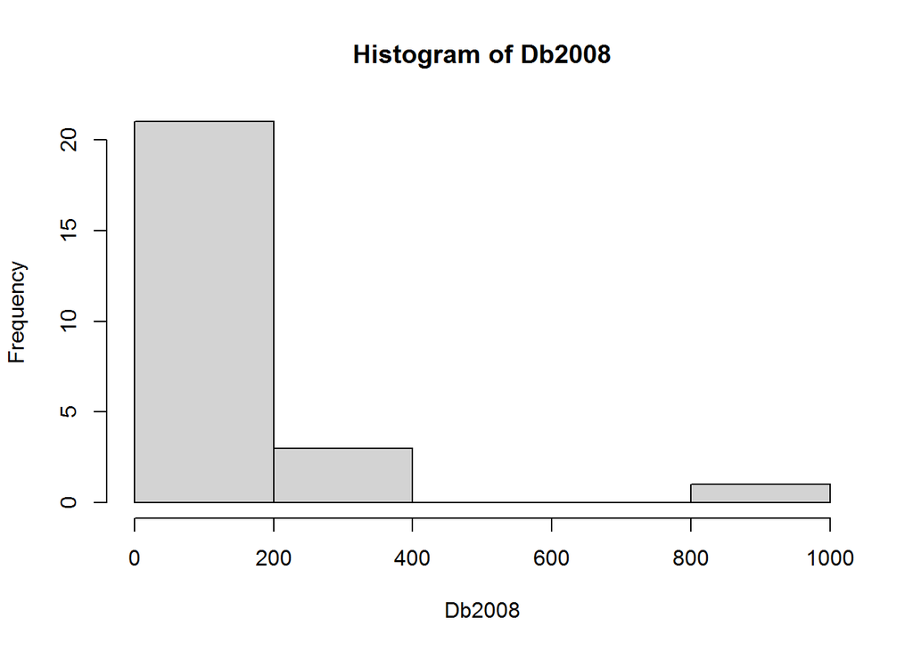

```r
hist(Db2008)
```

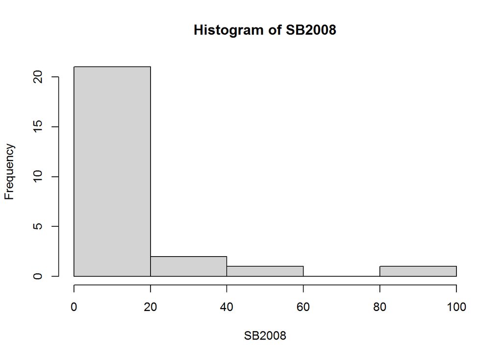

```r
hist(SB2008)
```

categorical Data - Barplot

```r
table(Db2008)
```

```
## Db2008
##   1   3   4  12  13  20  23  27  35  40  69  71  84  89  95 101 135 137 305 308
##   2   2   1   1   1   1   1   1   1   1   1   1   1   1   1   1   1   2   1   1
## 381 880
##   1   1
```

```r
table(SB2008)
```

```
## SB2008
##  0.1  0.4  0.5  1.4  1.5  2.3  2.6  3.1    4  4.5  7.9  8.1  9.6 10.1 10.8 11.4
##    2    2    1    1    1    1    1    1    1    1    1    1    1    1    1    1
## 15.4 15.5 15.6 34.7   35 43.3  100
##    1    1    1    1    1    1    1
```

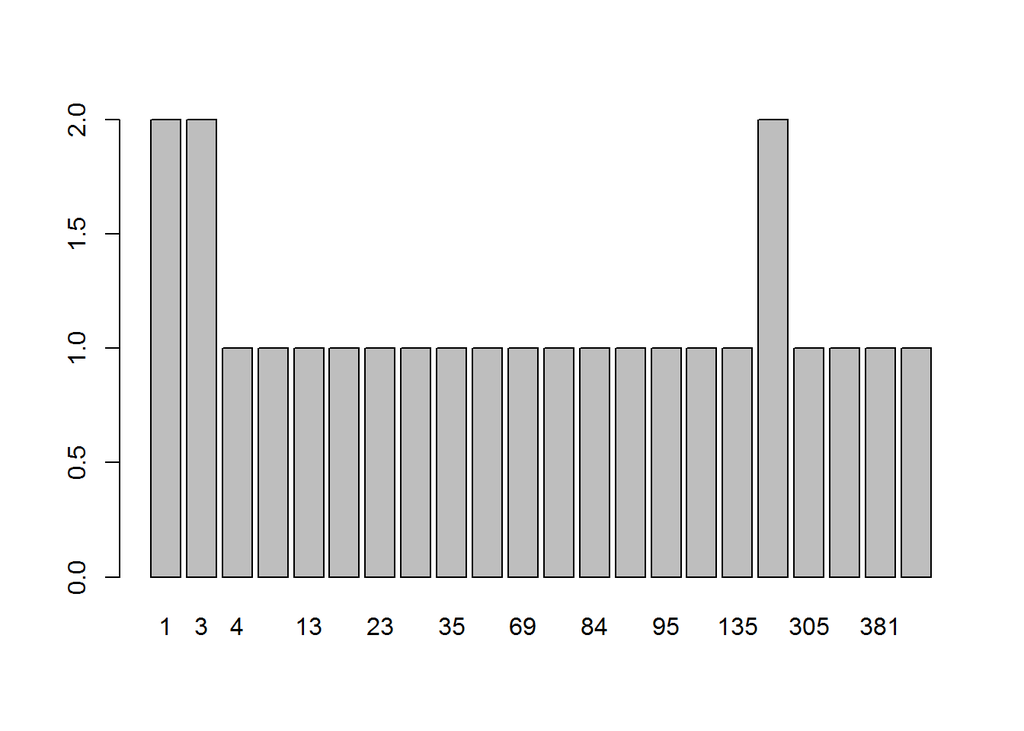

```r
barplot(table(Db2008))
```

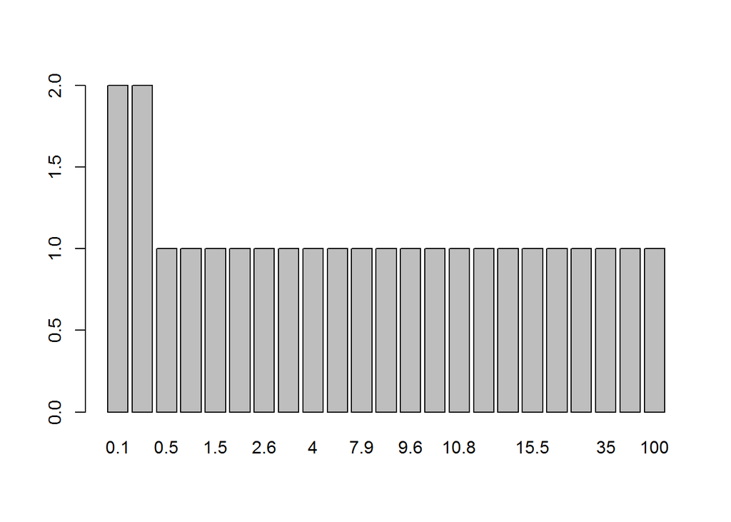

```r
barplot(table(SB2008))
```

### Preparing a dataset- Duration of broadcasts and Share of broadcasts for 2009

### Data Summarization

```r
Db2009 = mydata$X2009.Duration.of.broadcasts..minutes
SB2009 = mydata$X2009.Share.of.broadcasts...
```

### Central Tendencies

calculating the mean

```r
mean(Db2009)    #122.92
```

```
## [1] 122.92
```

```r
mean(SB2009)    #13.084
```

```
## [1] 13.084
```

Calculating the median

```r
median(Db2009)  #31
```

```
## [1] 31
```

```r
median(SB2009)  #3.3
```

```
## [1] 3.3
```

calculating the mode

```r
mode = function(x){

  ta = table(x)

  tam = max(ta)

  if(all(ta == tam))

    mod = NA

  else

    if(is.numeric(x))

      mod = as.numeric(names(ta)[ta == tam])

  else

    mod = names(ta)[ta == tam]

  return(mod)

}
mode(Db2009)  # 2 17
```

```
## [1]  2 17
```

```r
mode(SB2009) #0.2 1.8
```

```
## [1] 0.2 1.8
```

### Measuring the variability

calculating the standard Deviation

```r
sd(Db2009) #209.7747
```

```
## [1] 209.7747
```

```r
sd(SB2009) #22.3417
```

```
## [1] 22.3417
```

calculating iQR

```r
quantile(Db2009) # 1             13        31        112      939
```

```
##   0%  25%  50%  75% 100%
##    1   13   31  112  939
```

```r
quantile(SB2009) # 0.1          1.4       3.3       11.9     100.0
```

```
##    0%   25%   50%   75%  100%
##   0.1   1.4   3.3  11.9 100.0
```

### 3. Provide brief descriptive statistical analysis of your data set (like measures of central tendency and dispersion).

calculating variance where standard deviation measures how much data values are deviated from mean

```r
var(Db2009)   #44005.41
```

```
## [1] 44005.41
```

```r
var(SB2009)   #499.1514
```

```
## [1] 499.1514
```

### 4. Include at least one plot into your report. If ggplot2 is too complicated for you now, create a plot with R base functions.

numeric Data Barplot

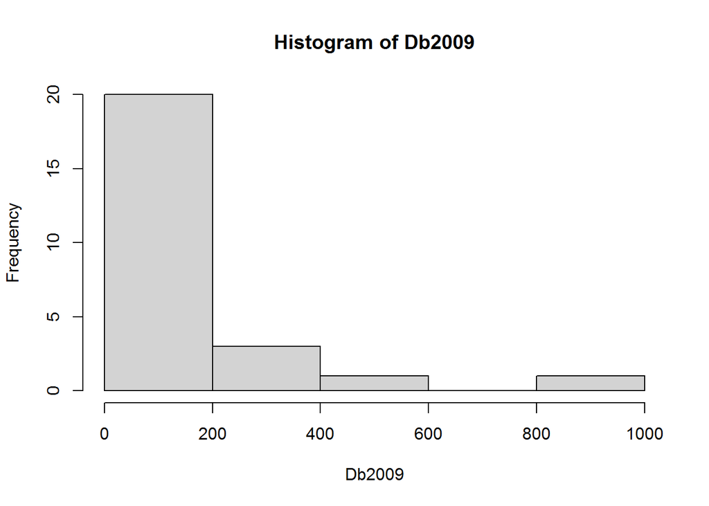

```r
hist(Db2009)
```

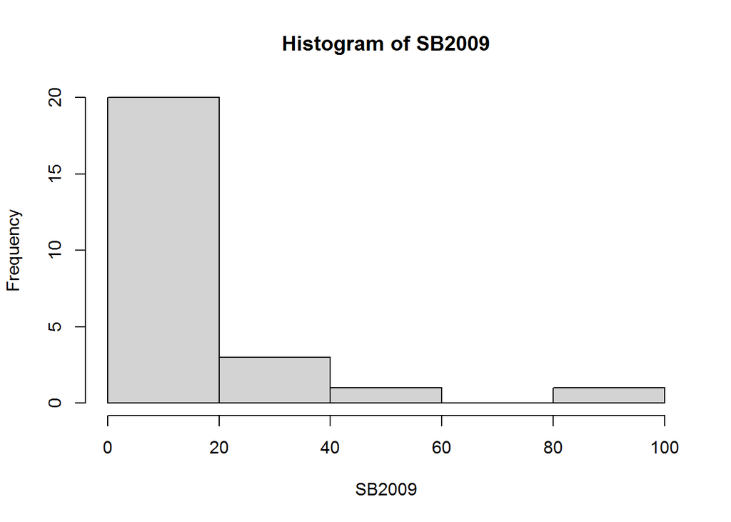

```r
hist(SB2009)
```

categorical Data - Barplot

```r
table(Db2009)
```

```
## Db2009
##   1   2   4   7  11  13  15  17  23  28  31  34  45  58  63 103 112 186 237 342
##   1   2   1   1   1   1   1   2   1   1   1   1   1   1   1   1   1   1   1   1
## 372 411 939
##   1   1   1
```